# Tutorial_4

Rich

2025-11-19

Tutorial 4 shows one way to plan the design of a future experiment using EHA.

# 1. Load the libraries that we will be using

```r
pkg <- c(
  "cmdstanr", "standist", "tidyverse", "RColorBrewer", "patchwork",
  "brms", "tidybayes", "bayesplot", "future", "parallel", "VGAM", "faux",
  "rstan", "osfr", "here"
)

lapply(pkg, library, character.only = TRUE)
```

```
## This is cmdstanr version 0.9.0.9000
```

```
## - CmdStanR documentation and vignettes: mc-stan.org/cmdstanr
```

```
## - CmdStan path: /Users/spanis/.cmdstan/cmdstan-2.36.0
```

```
## - CmdStan version: 2.36.0
```

```
##
## A newer version of CmdStan is available. See ?install_cmdstan() to install it.
## To disable this check set option or environment variable cmdstanr_no_ver_check=TRUE.
```

[output not shown]

Set options.

```r
options(
  brms.backend = "cmdstanr",
  mc.cores = parallel::detectCores(),
  future.fork.enable = TRUE,
  future.rng.onMisuse = "ignore"
) ## automatically set in RStudio

rstan_options(auto_write = TRUE)

supportsMulticore()
detectCores()
```

```r
# packageVersion("cmdstanr")
# devtools::session_info("rstan")
```

theme settings for ggplot

```r
theme_set(
  theme_bw() +
    theme(
      text = element_text(size = 22, face = "bold"),
      title = element_text(size = 22, face = "bold"),
      legend.position = "bottom"
    )
)

## Set the amount of dodge in figures
pd <- position_dodge(0.7)
pd2 <- position_dodge(1)
```

# 2. A brief outline of the workflow

## 2.1 - Main background sources

The basic approach is based upon two main sources:

The basic structure and code follows the examples outlined by Solomon Kurz in his ‘power’ blog posts and Lisa Debruine’s faux{} package.

For Solomon’s blog posts, see here: https://solomonkurz.netlify.app/tags/power/

For Lisa’s faux package, see here: https://debruine.github.io/faux/. The vignettes provided by the faux package are particularly helpful and worth following before you take a deep dive into the below code. There is also an associated [journal article](https://doi.org/10.1177/2515245920965119), which is worth reading.

And for some simpler worked examples of the general workflow (i.e., simpler than using EHA), then take a look at these examples by Rich, which show how you might simulate multi-level data for a range of factorial designs: https://github.com/rich-ramsey/sim_demo

## 2.2 - Basic workflow

The basic workflow is as follows:

1. Fit a regression model to existing data.
2. Use the regression model parameters to simulate new data.
3. Write a function to create 1000s of datasets and vary parameters of interest (e.g., sample size, trial count, effect size).
4. Summarise the simulated data to estimate likely power or precision of the various research designs.

## 2.3 - Exceptions to the normal workflow

The basic workflow above is a modified version of that recommended by Solomon and Lisa. In a typical workflow, once the datasets are simulated, a regression model would be fit to each dataset. Then, the parameters from each model would be summarised to make a judgment about the likely precision or power of the design. However, in the case of some of the models in this tutorial, which can take several hours to build, we are not able to easily build 1000 models per variation in parameter setting, such as sample size and/or trial count, as that would take an unreasonably long time on a desktop machine. Instead, we choose to take a simpler approach and summarise the data per bin and condition, rather than the parameter estimates from the model. Although this is not as satisfying, we feel it can still be a useful guide to set expectations. To further save time and computational resources, for the purposes of this planning tutorial, we also choose to use a smaller dataset than was used in the earlier tutorials. The details on this simpler dataset and modelling procedure are provided below.

# 3. Read in the data

Here, we again use data form Panis and Schmidt (2016), but to make things simpler, we focus on only 6 time bins (time bins 4-9) and two prime conditions (congruent and incongruent).

## read in and wrangle the raw data

```r
data <- read_csv("Tutorial_4_planning/data/tidyppp_Exp1_n6.csv") |>
  ## no mask condition only, neutral prime removed, time bins 4-9 only
  filter(no_ma == 1, no_pr < 1, timebin %in% c(4:9)) |>
  ## remove unnecessary columns
  select(-c(bl, target_dir, corresp, resp, respac, rel_ma, irr_ma, ran_ma, no_ma)) |>
  ## rename the error column
  rename(error = resperr) |>
  ## create a new variable and some factors
  mutate(
    prime = if_else(con_pr == 1, "con", "inc"),
    prime = factor(prime,
      levels = c("con", "inc")
    ),
    timebin = factor(timebin)
  ) |>
  ## simplify the data by selecting a few variables only
  select(pid, timebin, prime, outcome)
head(data)
```

```
## # A tibble: 6 × 4
##     pid timebin prime outcome
##   <dbl> <fct>   <fct>   <dbl>
## 1     1 4       con         0
## 2     1 5       con         0
## 3     1 6       con         0
## 4     1 7       con         0
## 5     1 8       con         0
## 6     1 9       con         0
```

```r
str(data)
```

```
## tibble [7,385 × 4] (S3: tbl_df/tbl/data.frame)
##  $ pid    : num [1:7385] 1 1 1 1 1 1 1 1 1 1 ...
##  $ timebin: Factor w/ 6 levels "4","5","6","7",..: 1 2 3 4 5 6 1 2 3 4 ...
##  $ prime  : Factor w/ 2 levels "con","inc": 1 1 1 1 1 1 2 2 2 2 ...
##  $ outcome: num [1:7385] 0 0 0 0 0 0 0 0 0 0 ...
```

data check

```r
data |>
  distinct(timebin, prime)
```

```
## # A tibble: 12 × 2
##    timebin prime
##    <fct>   <fct>
##  1 4       con
##  2 5       con
##  3 6       con
##  4 7       con
##  5 8       con
##  6 9       con
##  7 4       inc
##  8 5       inc
##  9 6       inc
## 10 7       inc
## 11 8       inc
## 12 9       inc
```

## create summary data

summary data

```r
data_pid <- data |>
  group_by(pid, timebin, prime) |>
  summarise(outcome = mean(outcome, na.rm = TRUE))
head(data_pid)
```

```
## # A tibble: 6 × 4
## # Groups:   pid, timebin [3]
##     pid timebin prime outcome
##   <dbl> <fct>   <fct>   <dbl>
## 1     1 4       con    0
## 2     1 4       inc    0
## 3     1 5       con    0
## 4     1 5       inc    0
## 5     1 6       con    0.0667
## 6     1 6       inc    0.075
```

```r
data_group <- data |>
  group_by(timebin, prime) |>
  summarise(outcome = mean(outcome, na.rm = TRUE))
head(data_group)
```

```
## # A tibble: 6 × 3
## # Groups:   timebin [3]
##   timebin prime outcome
##   <fct>   <fct>   <dbl>
## 1 4       con   0.00975
## 2 4       inc   0.0139
## 3 5       con   0.0478
## 4 5       inc   0.0423
## 5 6       con   0.0901
## 6 6       inc   0.0913
```

quick plot

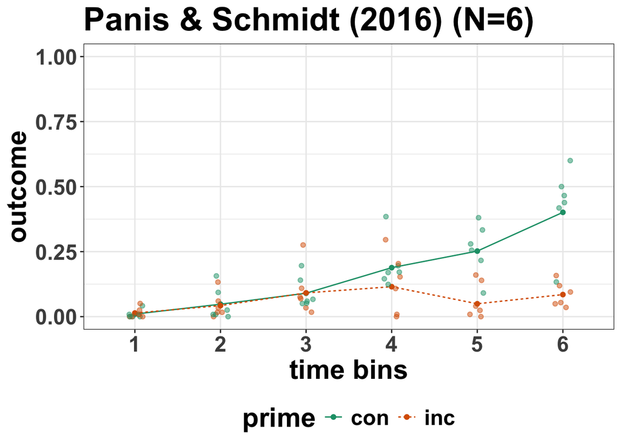

```r
p3.1 <- ggplot(data_group, aes(x = timebin, y = outcome, colour = prime)) +
  geom_line(aes(group = prime, linetype = prime)) +
  geom_point() +
  geom_jitter(data = data_pid, alpha = 0.5, width = 0.1, height = 0) +
  scale_y_continuous(limits = c(0, 1), breaks = seq(0, 1, 0.25)) +
  scale_x_discrete(labels = c(1:6)) +
  scale_fill_brewer(palette = "Dark2") +
  scale_colour_brewer(palette = "Dark2") +
  labs(
    title = "Panis & Schmidt (2016) (N=6)",
    x = "time bins"
  )
p3.1
```

check the number of trials

```r
tally <- data |>
  group_by(pid, prime, timebin) |>
  summarise(
    n = n(),
    sum = sum(outcome),
    .groups = "drop"
  )
tally
```

```
## # A tibble: 72 × 5
##      pid prime timebin     n   sum
##    <dbl> <fct> <fct>   <int> <dbl>
##  1     1 con   4         120     0
##  2     1 con   5         120     0
##  3     1 con   6         120     8
##  4     1 con   7         112    19
##  5     1 con   8          93    26
##  6     1 con   9          67    28
##  7     1 inc   4         120     0
##  8     1 inc   5         120     0
##  9     1 inc   6         120     9
## 10     1 inc   7         111    12
## # ℹ 62 more rows
```

# 4. Build an initial model

In general, it can sometimes be a lot simpler to use an index coding approach to build regression models.

see this link for some background on an index coding approach: https://bookdown.org/content/4857/the-many-variables-the-spurious-waffles.html#many-categories.

and then maybe specify the interaction term like this… https://discourse.mc-stan.org/t/specifying-formulates-for-interaction-between-categorical-variables-with-the-index-coding-approach-in-brms/29449/3

And in the context of data simulation, index coding can be particularly useful, because it may be often easier and more intuitive to set condition means, rather than more complicated regression parameters, such as interaction terms.

The approach here is to build an initial model using an index coding approach, but with a subset of the data that was used in prior tutorials.

Because we are building Bayesian regression models, which generate a posterior distribution per condition of interest in our index coding approach, we can simply calculate contrasts of interests and associated precision or interval estimates (95% quantile intervals, for example) to address any questions we may have about comparisons between conditions, such as incongruent vs congruent in a particular time bin.

## formula

with varying intercept and slope for prime by pid

```r
formula <- bf(outcome ~ 0 + timebin:prime +
  (0 + timebin:prime | pid))
```

## check the priors available

```r
get_prior(formula,
  data = data, family = bernoulli(link = "cloglog")
)
```

```
##                 prior class              coef group resp dpar nlpar lb ub
##                (flat)     b
##                (flat)     b timebin4:primecon
##                (flat)     b timebin4:primeinc
##                (flat)     b timebin5:primecon
##                (flat)     b timebin5:primeinc
##                (flat)     b timebin6:primecon
##                (flat)     b timebin6:primeinc
##                (flat)     b timebin7:primecon
##                (flat)     b timebin7:primeinc
##                (flat)     b timebin8:primecon
##                (flat)     b timebin8:primeinc
##                (flat)     b timebin9:primecon
##                (flat)     b timebin9:primeinc
##                lkj(1)   cor
##                lkj(1)   cor                     pid
##  student_t(3, 0, 2.5)    sd                                          0
##  student_t(3, 0, 2.5)    sd                     pid                  0
##  student_t(3, 0, 2.5)    sd timebin4:primecon   pid                  0
##  student_t(3, 0, 2.5)    sd timebin4:primeinc   pid                  0
##  student_t(3, 0, 2.5)    sd timebin5:primecon   pid                  0
##  student_t(3, 0, 2.5)    sd timebin5:primeinc   pid                  0
##  student_t(3, 0, 2.5)    sd timebin6:primecon   pid                  0
##  student_t(3, 0, 2.5)    sd timebin6:primeinc   pid                  0
##  student_t(3, 0, 2.5)    sd timebin7:primecon   pid                  0
##  student_t(3, 0, 2.5)    sd timebin7:primeinc   pid                  0
##  student_t(3, 0, 2.5)    sd timebin8:primecon   pid                  0
##  student_t(3, 0, 2.5)    sd timebin8:primeinc   pid                  0
##  student_t(3, 0, 2.5)    sd timebin9:primecon   pid                  0
##  student_t(3, 0, 2.5)    sd timebin9:primeinc   pid                  0
##        source
##       default
##  (vectorized)
##  (vectorized)
##  (vectorized)
##  (vectorized)
##  (vectorized)
##  (vectorized)
##  (vectorized)
##  (vectorized)
##  (vectorized)
##  (vectorized)
##  (vectorized)
##  (vectorized)
##       default
##  (vectorized)
##       default
##  (vectorized)
##  (vectorized)
##  (vectorized)
##  (vectorized)
##  (vectorized)
##  (vectorized)
##  (vectorized)
##  (vectorized)
##  (vectorized)
##  (vectorized)
##  (vectorized)
##  (vectorized)
##  (vectorized)
```

## visualise priors

For a look at values across the cloglog scale and how it compares to the logit scale, see [here](https://towardsdatascience.com/a-gentle-introduction-to-complementary-log-log-regression-8ac3c5c1cd83).

Ok, so let’s take a look at some cloglog values at the lower and upper end of the probability scale.

```r
cloglog_vals <- clogloglink(c(0.01, 0.99))
cloglog_vals
```

```
## [1] -4.600149  1.527180
```

```r
# -4.600149  1.527180
```

and now take a look at some distributions

```r
visualize("normal(0, 2)", "normal(0, 1)", "normal(0, 0.5)",
  xlim = c(-4, 4)
)
```

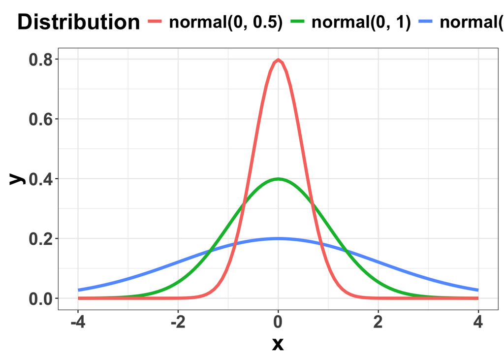

(0,2) looks like it covers all of our likely values, even if it is too broad.

For simplicity, we use these normal(0,2) priors for the mean per condition. However, if we were doing this for real, we would probably choose different priors that are similar to ones that were discussed in Tutorial_2a, as well as in Supplementary Materials.

## set priors

We set the prior for the mean as (normal(0,2)) and then we use some default recommendations from McElreath 2020 for the rest.

```r
priors <- c(
  set_prior("normal(0, 2)", class = "b"),
  set_prior("normal(0, 1)", class = "sd"),
  set_prior("lkj(2)", class = "cor")
)
```

## run the model

This model takes ~17 minutes to build on a 2020 MacBook Pro (2 GHz Quad-Core Intel Core i5). For this tutorial, this chunk is skipped to save time. Change eval=TRUE in the code chunk to run this model.

```r
plan(multicore)
bi <- brm(
  formula = formula,
  data = data, family = bernoulli(link = "cloglog"),
  prior = priors,
  iter = 2000, warmup = 1000, cores = 8, chains = 4,
  control = list(adapt_delta = 0.95),
  save_pars = save_pars(all = TRUE),
  seed = 123,
  init = 0.01,
  file = "Tutorial_4_planning/models/bi"
)
summary(bi)
```

The model built without any concerns, errors or warnings.

At this point, you would normally do the following:

- check the model by looking at the convergence of chains and other model diagnostics. We’ll skip this step for now, just to move on to the main focus of planning and data simulation.
- Summarise and visualise the parameter estimates and/or posterior predictions.

Below, we quickly summarise fixed effects from the model in cloglog values, and we also convert them to hazard values, which tend to be far easier to interpret.

## visualise fixed effect parameters from model bi

read in the existing model object (if you did not build the model yourself)

```r
bi <- readRDS("Tutorial_4_planning/models/bi.rds")
summary(bi)
```

```
##  Family: bernoulli
##   Links: mu = cloglog
## Formula: outcome ~ 0 + timebin:prime + (0 + timebin:prime | pid)
##    Data: data (Number of observations: 7385)
##   Draws: 4 chains, each with iter = 2000; warmup = 1000; thin = 1;
##          total post-warmup draws = 4000
##
## Multilevel Hyperparameters:
## ~pid (Number of levels: 6)
##                                          Estimate Est.Error l-95% CI u-95% CI
## sd(timebin4:primecon)                        1.06      0.53     0.15     2.24
## sd(timebin5:primecon)                        1.34      0.44     0.66     2.35
## sd(timebin6:primecon)                        0.60      0.26     0.25     1.26
## sd(timebin7:primecon)                        0.47      0.21     0.19     0.98
## sd(timebin8:primecon)                        0.58      0.25     0.24     1.24
## sd(timebin9:primecon)                        0.72      0.28     0.34     1.41
## sd(timebin4:primeinc)                        1.17      0.52     0.31     2.37
## sd(timebin5:primeinc)                        1.05      0.41     0.46     2.06
## sd(timebin6:primeinc)                        0.91      0.32     0.45     1.67
## sd(timebin7:primeinc)                        1.47      0.43     0.77     2.44
## sd(timebin8:primeinc)                        1.34      0.43     0.67     2.33
## sd(timebin9:primeinc)                        0.62      0.32     0.12     1.38
## cor(timebin4:primecon,timebin5:primecon)     0.18      0.24    -0.30     0.60
## cor(timebin4:primecon,timebin6:primecon)     0.14      0.25    -0.35     0.59
## cor(timebin5:primecon,timebin6:primecon)     0.19      0.23    -0.27     0.63
## cor(timebin4:primecon,timebin7:primecon)     0.15      0.24    -0.33     0.60
## cor(timebin5:primecon,timebin7:primecon)     0.15      0.24    -0.32     0.60
## cor(timebin6:primecon,timebin7:primecon)     0.16      0.24    -0.32     0.61
## cor(timebin4:primecon,timebin8:primecon)     0.06      0.25    -0.41     0.53
## cor(timebin5:primecon,timebin8:primecon)     0.00      0.23    -0.44     0.45
## cor(timebin6:primecon,timebin8:primecon)     0.03      0.24    -0.44     0.49
## cor(timebin7:primecon,timebin8:primecon)     0.08      0.24    -0.40     0.54
## cor(timebin4:primecon,timebin9:primecon)     0.08      0.25    -0.41     0.55
## cor(timebin5:primecon,timebin9:primecon)     0.09      0.23    -0.38     0.52
## cor(timebin6:primecon,timebin9:primecon)     0.05      0.24    -0.43     0.51
## cor(timebin7:primecon,timebin9:primecon)     0.05      0.24    -0.41     0.52
## cor(timebin8:primecon,timebin9:primecon)     0.18      0.24    -0.31     0.62
## cor(timebin4:primecon,timebin4:primeinc)     0.16      0.25    -0.34     0.61
## cor(timebin5:primecon,timebin4:primeinc)     0.22      0.23    -0.24     0.65
## cor(timebin6:primecon,timebin4:primeinc)     0.17      0.24    -0.32     0.61
```

[output cut: 131 more lines]

```
## timebin5:primecon    -3.24      0.61    -4.43    -2.01 1.00     1680     1803
## timebin6:primecon    -2.32      0.30    -2.93    -1.72 1.00     2041     2286
## timebin7:primecon    -1.49      0.23    -1.96    -1.02 1.00     2030     1901
## timebin8:primecon    -1.21      0.28    -1.77    -0.63 1.00     1783     1971
## timebin9:primecon    -0.60      0.32    -1.23     0.07 1.00     1931     2216
## timebin4:primeinc    -4.37      0.61    -5.57    -3.13 1.00     2868     2386
## timebin5:primeinc    -3.21      0.50    -4.18    -2.19 1.00     2349     2460
## timebin6:primeinc    -2.37      0.41    -3.12    -1.48 1.00     2078     2205
## timebin7:primeinc    -2.27      0.64    -3.56    -0.99 1.00     2088     2403
## timebin8:primeinc    -3.04      0.59    -4.14    -1.80 1.00     2662     2729
## timebin9:primeinc    -2.45      0.32    -3.11    -1.79 1.00     3116     2732
##
## Draws were sampled using sample(hmc). For each parameter, Bulk_ESS
## and Tail_ESS are effective sample size measures, and Rhat is the potential
## scale reduction factor on split chains (at convergence, Rhat = 1).
```

wrangle the posterior distribution

```r
## take the posterior draws
post <- as_draws_df(bi) |>
  select(-lp__) |>
  as_tibble()

## create a summary, and use medians with robust = TRUE
post_summary <- posterior_summary(bi, robust = TRUE)

## just look at the fixed effects
post_qi_b <- post |>
  select(starts_with("b_")) |>
  pivot_longer(everything()) |>
  group_by(name) |>
  median_qi(value)
head(post_qi_b)
```

```
## # A tibble: 6 × 7
##   name                value .lower .upper .width .point .interval
##   <chr>               <dbl>  <dbl>  <dbl>  <dbl> <chr>  <chr>
## 1 b_timebin4:primecon -4.63  -5.96  -3.44   0.95 median qi
## 2 b_timebin4:primeinc -4.35  -5.57  -3.13   0.95 median qi
## 3 b_timebin5:primecon -3.24  -4.43  -2.01   0.95 median qi
## 4 b_timebin5:primeinc -3.21  -4.18  -2.19   0.95 median qi
## 5 b_timebin6:primecon -2.32  -2.93  -1.72   0.95 median qi
## 6 b_timebin6:primeinc -2.38  -3.12  -1.48   0.95 median qi
```

a quick plot using posterior samples and tidybayes

```r
tidy_fixed <- post |>
  select(starts_with("b_"), .chain, .iteration, .draw) |> # select and rename in simpler labels.
  rename(chain = .chain, iter = .iteration, draw = .draw) |>
  pivot_longer(-c(chain, draw, iter)) |> # move from wide to long
  mutate(
    key = factor(name, levels = unique(name)),
    bin = rep(1:6, length.out = 48000),
    prime = rep(c("con", "inc"), each = 6, length.out = 48000),
    bin = factor(bin),
    prime = factor(prime)
  )
head(tidy_fixed)
```

```
## # A tibble: 6 × 8
##   chain  iter  draw name                 value key                 bin   prime
##   <int> <int> <int> <chr>                <dbl> <fct>               <fct> <fct>
## 1     1     1     1 b_timebin4:primecon -6.09  b_timebin4:primecon 1     con
## 2     1     1     1 b_timebin5:primecon -2.32  b_timebin5:primecon 2     con
## 3     1     1     1 b_timebin6:primecon -2.78  b_timebin6:primecon 3     con
## 4     1     1     1 b_timebin7:primecon -1.40  b_timebin7:primecon 4     con
## 5     1     1     1 b_timebin8:primecon -1.32  b_timebin8:primecon 5     con
## 6     1     1     1 b_timebin9:primecon -0.472 b_timebin9:primecon 6     con
```

```r
tail(tidy_fixed)
```

```
## # A tibble: 6 × 8
##   chain  iter  draw name                value key                 bin   prime
##   <int> <int> <int> <chr>               <dbl> <fct>               <fct> <fct>
## 1     4  1000  4000 b_timebin4:primeinc -4.50 b_timebin4:primeinc 1     inc
## 2     4  1000  4000 b_timebin5:primeinc -3.07 b_timebin5:primeinc 2     inc
## 3     4  1000  4000 b_timebin6:primeinc -1.23 b_timebin6:primeinc 3     inc
## 4     4  1000  4000 b_timebin7:primeinc -2.26 b_timebin7:primeinc 4     inc
## 5     4  1000  4000 b_timebin8:primeinc -3.07 b_timebin8:primeinc 5     inc
## 6     4  1000  4000 b_timebin9:primeinc -2.34 b_timebin9:primeinc 6     inc
```

```r
check.labels <- tidy_fixed |>
  distinct(key, bin, prime)
check.labels
```

```
## # A tibble: 12 × 3
##    key                 bin   prime
##    <fct>               <fct> <fct>
##  1 b_timebin4:primecon 1     con
##  2 b_timebin5:primecon 2     con
##  3 b_timebin6:primecon 3     con
##  4 b_timebin7:primecon 4     con
##  5 b_timebin8:primecon 5     con
##  6 b_timebin9:primecon 6     con
##  7 b_timebin4:primeinc 1     inc
##  8 b_timebin5:primeinc 2     inc
##  9 b_timebin6:primeinc 3     inc
## 10 b_timebin7:primeinc 4     inc
## 11 b_timebin8:primeinc 5     inc
## 12 b_timebin9:primeinc 6     inc
```

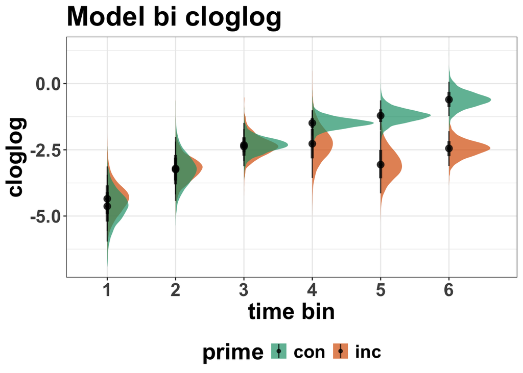

```r
# plot
p4.1 <- ggplot(tidy_fixed, aes(x = bin, y = value, fill = prime)) +
  stat_halfeye(alpha = 0.7) +
  labs(
    title = "Model bi cloglog",
    x = "time bin", y = "cloglog"
  ) +
  scale_fill_brewer(palette = "Dark2")
p4.1
```

```r
ggsave("Tutorial_4_planning/figures/index_cloglog.jpeg",
  width = 6, height = 4, dpi = 800
)
```

calculate hazards per condition per bin in the posterior dist

```r
tidy_haz <- tidy_fixed |>
  select(chain, iter, draw, bin, prime, value) |>
  mutate(hazard = exp(value))
head(tidy_haz)
```

```
## # A tibble: 6 × 7
##   chain  iter  draw bin   prime  value  hazard
##   <int> <int> <int> <fct> <fct>  <dbl>   <dbl>
## 1     1     1     1 1     con   -6.09  0.00227
## 2     1     1     1 2     con   -2.32  0.0981
## 3     1     1     1 3     con   -2.78  0.0619
## 4     1     1     1 4     con   -1.40  0.247
## 5     1     1     1 5     con   -1.32  0.266
## 6     1     1     1 6     con   -0.472 0.624
```

plot hazards

```
## Warning: Removed 166 rows containing missing values or values outside the scale range
## (`stat_slabinterval()`).
```

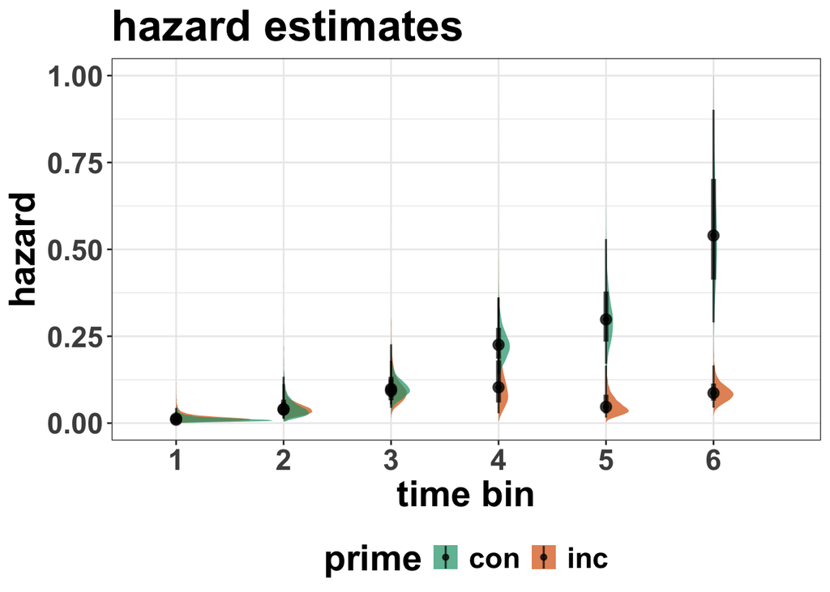

```r
p4.2 <- ggplot(tidy_haz, aes(
  x = bin, y = hazard,
  fill = prime
)) +
  stat_halfeye(alpha = 0.7) +
  labs(
    title = "hazard estimates",
    x = "time bin", y = "hazard"
  ) +
  scale_fill_brewer(palette = "Dark2") +
  scale_y_continuous(limits = c(0, 1), breaks = seq(0, 1, 0.25))
p4.2
```

```r
ggsave("Tutorial_4_planning/figures/index_hazard.jpeg",
  width = 6, height = 4, dpi = 800
)
```

warning about removing rows.

# 5. Simulate a single dataset

Note: For multi-level data, data simulation can be quite a convoluted process, and we therefore strongly recommend reading the power blogs by Solomon Kurz and working through the faux package [vignettes](https://debruine.github.io/faux/index.html), before getting stuck into the below code.

read in a prior model, if not already loaded.

```r
bi <- readRDS("Tutorial_4_planning/models/bi.rds")
summary(bi)
```

Define some parameters

```r
# define parameters
# specify some features of the design
subj_n <- 10 # number of subjects
rep_n <- 200 # number of trial repeats
cond_n <- 2 # number of conditions
bin_n <- 6 # number of time bins

## set fixed effects
## as a reminder
fixef <- as_tibble(fixef(bi), rownames = "term") |>
  mutate(across(where(is.double), \(x) round(x, 2)))
fixef
```

```
## # A tibble: 12 × 5
##    term              Estimate Est.Error  Q2.5 Q97.5
##    <chr>                <dbl>     <dbl> <dbl> <dbl>
##  1 timebin4:primecon    -4.66      0.63 -5.96 -3.44
##  2 timebin5:primecon    -3.24      0.61 -4.43 -2.01
##  3 timebin6:primecon    -2.32      0.3  -2.93 -1.72
##  4 timebin7:primecon    -1.49      0.23 -1.96 -1.02
##  5 timebin8:primecon    -1.21      0.28 -1.77 -0.63
##  6 timebin9:primecon    -0.6       0.32 -1.23  0.07
##  7 timebin4:primeinc    -4.37      0.61 -5.57 -3.13
##  8 timebin5:primeinc    -3.21      0.5  -4.18 -2.19
##  9 timebin6:primeinc    -2.37      0.41 -3.12 -1.48
## 10 timebin7:primeinc    -2.27      0.64 -3.56 -0.99
## 11 timebin8:primeinc    -3.04      0.59 -4.14 -1.8
## 12 timebin9:primeinc    -2.45      0.32 -3.11 -1.79
```

```r
## b1 to b6 = time bin 1 to 6.
## c = con
b1c <- -4.66
b2c <- -3.24
b3c <- -2.32
b4c <- -1.49
b5c <- -1.21
b6c <- -0.60

## i = inc
b1i <- -4.37
b2i <- -3.21
b3i <- -2.37
b4i <- -2.27
b5i <- -3.04
b6i <- -2.45

## set varying effects by pid
## as a reminder
varcor <- VarCorr(bi)
glimpse(varcor)
```

```
## List of 1
##  $ pid:List of 3
##   ..$ sd : num [1:12, 1:4] 1.062 1.34 0.599 0.468 0.583 ...
##   .. ..- attr(*, "dimnames")=List of 2
##   ..$ cor: num [1:12, 1:4, 1:12] 1 0.1811 0.1402 0.1506 0.0557 ...
##   .. ..- attr(*, "dimnames")=List of 3
##   ..$ cov: num [1:12, 1:4, 1:12] 1.4119 0.2562 0.0839 0.069 0.0335 ...
##   .. ..- attr(*, "dimnames")=List of 3
```

```r
str(varcor)
```

```
## List of 1
##  $ pid:List of 3
##   ..$ sd : num [1:12, 1:4] 1.062 1.34 0.599 0.468 0.583 ...
##   .. ..- attr(*, "dimnames")=List of 2
##   .. .. ..$ : chr [1:12] "timebin4:primecon" "timebin5:primecon" "timebin6:primecon" "timebin7:primecon" ...
##   .. .. ..$ : chr [1:4] "Estimate" "Est.Error" "Q2.5" "Q97.5"
##   ..$ cor: num [1:12, 1:4, 1:12] 1 0.1811 0.1402 0.1506 0.0557 ...
##   .. ..- attr(*, "dimnames")=List of 3
##   .. .. ..$ : chr [1:12] "timebin4:primecon" "timebin5:primecon" "timebin6:primecon" "timebin7:primecon" ...
##   .. .. ..$ : chr [1:4] "Estimate" "Est.Error" "Q2.5" "Q97.5"
##   .. .. ..$ : chr [1:12] "timebin4:primecon" "timebin5:primecon" "timebin6:primecon" "timebin7:primecon" ...
##   ..$ cov: num [1:12, 1:4, 1:12] 1.4119 0.2562 0.0839 0.069 0.0335 ...
##   .. ..- attr(*, "dimnames")=List of 3
##   .. .. ..$ : chr [1:12] "timebin4:primecon" "timebin5:primecon" "timebin6:primecon" "timebin7:primecon" ...
##   .. .. ..$ : chr [1:4] "Estimate" "Est.Error" "Q2.5" "Q97.5"
##   .. .. ..$ : chr [1:12] "timebin4:primecon" "timebin5:primecon" "timebin6:primecon" "timebin7:primecon" ...
```

```r
## extract sd
sd <- as_tibble(varcor$pid$sd, rownames = "term") |>
  mutate(across(where(is.double), \(x) round(x, 2)))
sd
```

```
## # A tibble: 12 × 5
##    term              Estimate Est.Error  Q2.5 Q97.5
##    <chr>                <dbl>     <dbl> <dbl> <dbl>
##  1 timebin4:primecon     1.06      0.53  0.15  2.24
##  2 timebin5:primecon     1.34      0.44  0.66  2.35
##  3 timebin6:primecon     0.6       0.26  0.25  1.26
##  4 timebin7:primecon     0.47      0.21  0.19  0.98
##  5 timebin8:primecon     0.58      0.25  0.24  1.24
##  6 timebin9:primecon     0.72      0.28  0.34  1.41
##  7 timebin4:primeinc     1.17      0.52  0.31  2.37
##  8 timebin5:primeinc     1.05      0.41  0.46  2.06
##  9 timebin6:primeinc     0.91      0.32  0.45  1.67
## 10 timebin7:primeinc     1.47      0.43  0.77  2.44
## 11 timebin8:primeinc     1.34      0.43  0.67  2.33
## 12 timebin9:primeinc     0.62      0.32  0.12  1.38
```

```r
u1c_sd <- 1.06 #
u2c_sd <- 1.34 #
u3c_sd <- 0.60 #
u4c_sd <- 0.47 #
u5c_sd <- 0.58 #
u6c_sd <- 0.72 #

u1i_sd <- 1.17 #
u2i_sd <- 1.05 #
u3i_sd <- 0.91 #
u4i_sd <- 1.47 #
u5i_sd <- 1.34 #
u6i_sd <- 0.62 #
```

make a correlation matrix

```r
# varcor <- VarCorr(b3c_out)
# varcor
# str(varcor)

## take each one
sd <- varcor$pid$sd
cor <- varcor$pid$cor
cov <- varcor$pid$cov

## make it tidy
cor_mat_tidy <- as_tibble(cor, rownames = "term") |> ##
  rename_with(~ str_replace_all(.x, "\\.", "_")) |>
  pivot_longer(-term,
    values_to = "value",
    names_to = c("parameter", "term2"),
    names_pattern = "([a-zA-Z_\\d?]+)_([a-zA-Z:\\d?]+)"
  ) |> ## pivot longer and use names_pattern to select the parts of the column names to separate on. the above is regex for each bit between the separator ("-"). e.g., ([a-zA-Z]+\\d+). this looks for letters and digits before the first "_". This (\\d?) looks for the possibility of digits.
  ## the rest of this code just turns the variables into what we want
  filter(parameter == "Estimate") |>
  select(-parameter) |>
  pivot_wider(
    names_from = "term2",
    values_from = "value"
  ) |>
  select(-term)
head(cor_mat_tidy)
```

```
## # A tibble: 6 × 12
##   `timebin4:primecon` `timebin5:primecon` `timebin6:primecon`
##                 <dbl>               <dbl>               <dbl>
## 1              1                  0.181                0.140
## 2              0.181              1                    0.194
## 3              0.140              0.194                1
## 4              0.151              0.152                0.160
## 5              0.0557             0.00218              0.0334
## 6              0.0784             0.0865               0.0480
## # ℹ 9 more variables: `timebin7:primecon` <dbl>, `timebin8:primecon` <dbl>,
## #   `timebin9:primecon` <dbl>, `timebin4:primeinc` <dbl>,
## #   `timebin5:primeinc` <dbl>, `timebin6:primeinc` <dbl>,
## #   `timebin7:primeinc` <dbl>, `timebin8:primeinc` <dbl>,
## #   `timebin9:primeinc` <dbl>
```

```r
str(cor_mat_tidy)
```

```
## tibble [12 × 12] (S3: tbl_df/tbl/data.frame)
##  $ timebin4:primecon: num [1:12] 1 0.1811 0.1402 0.1506 0.0557 ...
##  $ timebin5:primecon: num [1:12] 0.18111 1 0.19399 0.15233 0.00218 ...
##  $ timebin6:primecon: num [1:12] 0.1402 0.194 1 0.1605 0.0334 ...
##  $ timebin7:primecon: num [1:12] 0.1506 0.1523 0.1605 1 0.0786 ...
##  $ timebin8:primecon: num [1:12] 0.05571 0.00218 0.03338 0.07859 1 ...
##  $ timebin9:primecon: num [1:12] 0.0784 0.0865 0.048 0.0548 0.181 ...
##  $ timebin4:primeinc: num [1:12] 0.157 0.2193 0.169 0.1509 0.0387 ...
##  $ timebin5:primeinc: num [1:12] 0.1534 0.2218 0.1637 0.1635 0.0405 ...
##  $ timebin6:primeinc: num [1:12] 0.1287 0.1457 0.1891 0.1826 0.0658 ...
##  $ timebin7:primeinc: num [1:12] 0.0853 0.0849 0.1443 0.143 0.2001 ...
##  $ timebin8:primeinc: num [1:12] 0.0739 0.031 0.0924 0.1406 0.1671 ...
##  $ timebin9:primeinc: num [1:12] 0.06086 0.03899 0.00569 0.04339 0.08991 ...
```

```r
## check with the model summary
# summary(bi)

## remove names and make a matrix as faux{} likes it like that
## full cor mat
cor_mat <- unname(as.matrix(cor_mat_tidy))
cor_mat
```

```
##             [,1]        [,2]        [,3]       [,4]        [,5]       [,6]
##  [1,] 1.00000000 0.181111610 0.140227052 0.15064403 0.055708399 0.07844122
##  [2,] 0.18111161 1.000000000 0.193985724 0.15232674 0.002180379 0.08649338
##  [3,] 0.14022705 0.193985724 1.000000000 0.16047883 0.033383923 0.04798801
##  [4,] 0.15064403 0.152326739 0.160478829 1.00000000 0.078594351 0.05482625
##  [5,] 0.05570840 0.002180379 0.033383923 0.07859435 1.000000000 0.18103101
##  [6,] 0.07844122 0.086493375 0.047988009 0.05482625 0.181031007 1.00000000
##  [7,] 0.15700680 0.219264583 0.168973923 0.15088219 0.038736009 0.08194166
##  [8,] 0.15340135 0.221750842 0.163709105 0.16348048 0.040533384 0.03581839
##  [9,] 0.12869470 0.145655326 0.189094128 0.18261210 0.065750253 0.01304757
## [10,] 0.08533370 0.084865176 0.144296210 0.14300113 0.200118561 0.11201101
## [11,] 0.07387438 0.030988328 0.092439132 0.14063153 0.167079452 0.01372982
## [12,] 0.06086174 0.038991659 0.005693736 0.04338987 0.089912956 0.15443839
##             [,7]        [,8]        [,9]       [,10]       [,11]        [,12]
##  [1,] 0.15700680  0.15340135  0.12869470  0.08533370  0.07387438  0.060861737
##  [2,] 0.21926458  0.22175084  0.14565533  0.08486518  0.03098833  0.038991659
##  [3,] 0.16897392  0.16370910  0.18909413  0.14429621  0.09243913  0.005693736
##  [4,] 0.15088219  0.16348048  0.18261210  0.14300113  0.14063153  0.043389867
##  [5,] 0.03873601  0.04053338  0.06575025  0.20011856  0.16707945  0.089912956
##  [6,] 0.08194166  0.03581839  0.01304757  0.11201101  0.01372982  0.154438395
##  [7,] 1.00000000  0.17417672  0.15048835  0.09722597  0.04902133  0.047558257
##  [8,] 0.17417672  1.00000000  0.15883356  0.11194773  0.11333808 -0.011738558
##  [9,] 0.15048835  0.15883356  1.00000000  0.21397253  0.18646605 -0.014087671
## [10,] 0.09722597  0.11194773  0.21397253  1.00000000  0.25374893 -0.012638958
## [11,] 0.04902133  0.11333808  0.18646605  0.25374893  1.00000000 -0.039673970
## [12,] 0.04755826 -0.01173856 -0.01408767 -0.01263896 -0.03967397  1.000000000
```

setup the data structure

```r
# make it reproducible
set.seed(1)

d1 <- add_random(subj = subj_n, rep = rep_n) |>
  add_within("subj", condition = c("cond1", "cond2")) |>
  add_contrast("condition", "treatment",
    add_cols = TRUE,
    colnames = c("cond")
  ) |>
  add_within("rep", bin = 1:bin_n) |>
  ### create new conditions here that respect the twelve levels b1c, b1i etc.
  mutate(
    con = if_else(condition == "cond1", 1, 0),
    inc = if_else(condition == "cond2", 1, 0)
  ) |>
  mutate(
    bin1 = if_else(bin == 1, 1, 0),
    bin2 = if_else(bin == 2, 1, 0),
    bin3 = if_else(bin == 3, 1, 0),
    bin4 = if_else(bin == 4, 1, 0),
    bin5 = if_else(bin == 5, 1, 0),
    bin6 = if_else(bin == 6, 1, 0)
  ) |>
  # add random effects
  add_ranef("subj",
    u1c = u1c_sd, u2c = u2c_sd, u3c = u3c_sd, u4c = u4c_sd,
    u5c = u5c_sd, u6c = u6c_sd,
    u1i = u1i_sd, u2i = u2i_sd, u3i = u3i_sd, u4i = u4i_sd,
    u5i = u5i_sd, u6i = u6i_sd,
    .cors = cor_mat
  ) |>
  # calculate logit
  mutate(cloglog = (b1c + u1c) * con * bin1 + (b2c + u2c) * con * bin2 +
    (b3c + u3c) * con * bin3 + (b4c + u4c) * con * bin4 +
    (b5c + u5c) * con * bin5 + (b6c + u6c) * con * bin6 +
    (b1i + u1i) * inc * bin1 + (b2i + u2i) * inc * bin2 +
    (b3i + u3i) * inc * bin3 + (b4i + u4i) * inc * bin4 +
    (b5i + u5i) * inc * bin5 + (b6i + u6i) * inc * bin6) |>
  # calculate inverse cloglog
  mutate(prob = clogloglink(cloglog, inverse = TRUE)) |>
  # calculate event
  mutate(event = rbinom(n(), 1, prob))
head(d1)
```

```
## # A tibble: 6 × 28
##   subj   rep    condition  cond   bin   con   inc  bin1  bin2  bin3  bin4  bin5
##   <chr>  <chr>  <fct>     <dbl> <int> <dbl> <dbl> <dbl> <dbl> <dbl> <dbl> <dbl>
## 1 subj01 rep001 cond1         0     1     1     0     1     0     0     0     0
## 2 subj01 rep001 cond1         0     2     1     0     0     1     0     0     0
## 3 subj01 rep001 cond1         0     3     1     0     0     0     1     0     0
## 4 subj01 rep001 cond1         0     4     1     0     0     0     0     1     0
## 5 subj01 rep001 cond1         0     5     1     0     0     0     0     0     1
## 6 subj01 rep001 cond1         0     6     1     0     0     0     0     0     0
## # ℹ 16 more variables: bin6 <dbl>, u1c <dbl>, u2c <dbl>, u3c <dbl>, u4c <dbl>,
## #   u5c <dbl>, u6c <dbl>, u1i <dbl>, u2i <dbl>, u3i <dbl>, u4i <dbl>,
## #   u5i <dbl>, u6i <dbl>, cloglog <dbl>, prob <dbl>, event <int>
```

```r
str(d1)
```

```
## tibble [24,000 × 28] (S3: tbl_df/tbl/data.frame)
##  $ subj     : chr [1:24000] "subj01" "subj01" "subj01" "subj01" ...
##  $ rep      : chr [1:24000] "rep001" "rep001" "rep001" "rep001" ...
##  $ condition: Factor w/ 2 levels "cond1","cond2": 1 1 1 1 1 1 2 2 2 2 ...
##   ..- attr(*, "contrasts")= num [1:2, 1] 0 1
##   .. ..- attr(*, "dimnames")=List of 2
##   .. .. ..$ : chr [1:2] "cond1" "cond2"
##   .. .. ..$ : chr "cond"
##  $ cond     : num [1:24000] 0 0 0 0 0 0 1 1 1 1 ...
##  $ bin      : int [1:24000] 1 2 3 4 5 6 1 2 3 4 ...
##  $ con      : num [1:24000] 1 1 1 1 1 1 0 0 0 0 ...
##  $ inc      : num [1:24000] 0 0 0 0 0 0 1 1 1 1 ...
##  $ bin1     : num [1:24000] 1 0 0 0 0 0 1 0 0 0 ...
##  $ bin2     : num [1:24000] 0 1 0 0 0 0 0 1 0 0 ...
##  $ bin3     : num [1:24000] 0 0 1 0 0 0 0 0 1 0 ...
```

[output cut: 18 more lines]

```r
summary(d1)
```

```
##      subj               rep            condition          cond
##  Length:24000       Length:24000       cond1:12000   Min.   :0.0
##  Class :character   Class :character   cond2:12000   1st Qu.:0.0
##  Mode  :character   Mode  :character                 Median :0.5
##                                                      Mean   :0.5
##                                                      3rd Qu.:1.0
##                                                      Max.   :1.0
##       bin           con           inc           bin1             bin2
##  Min.   :1.0   Min.   :0.0   Min.   :0.0   Min.   :0.0000   Min.   :0.0000
##  1st Qu.:2.0   1st Qu.:0.0   1st Qu.:0.0   1st Qu.:0.0000   1st Qu.:0.0000
##  Median :3.5   Median :0.5   Median :0.5   Median :0.0000   Median :0.0000
##  Mean   :3.5   Mean   :0.5   Mean   :0.5   Mean   :0.1667   Mean   :0.1667
##  3rd Qu.:5.0   3rd Qu.:1.0   3rd Qu.:1.0   3rd Qu.:0.0000   3rd Qu.:0.0000
##  Max.   :6.0   Max.   :1.0   Max.   :1.0   Max.   :1.0000   Max.   :1.0000
##       bin3             bin4             bin5             bin6
##  Min.   :0.0000   Min.   :0.0000   Min.   :0.0000   Min.   :0.0000
##  1st Qu.:0.0000   1st Qu.:0.0000   1st Qu.:0.0000   1st Qu.:0.0000
##  Median :0.0000   Median :0.0000   Median :0.0000   Median :0.0000
##  Mean   :0.1667   Mean   :0.1667   Mean   :0.1667   Mean   :0.1667
##  3rd Qu.:0.0000   3rd Qu.:0.0000   3rd Qu.:0.0000   3rd Qu.:0.0000
##  Max.   :1.0000   Max.   :1.0000   Max.   :1.0000   Max.   :1.0000
##       u1c                u2c               u3c                u4c
##  Min.   :-1.48460   Min.   :-3.4790   Min.   :-0.80094   Min.   :-0.50119
##  1st Qu.:-0.08369   1st Qu.: 0.0192   1st Qu.:-0.16730   1st Qu.:-0.13584
##  Median : 0.27455   Median : 0.1766   Median : 0.09514   Median :-0.05036
##  Mean   : 0.10650   Mean   : 0.2040   Mean   : 0.12183   Mean   :-0.02763
##  3rd Qu.: 0.58677   3rd Qu.: 1.0012   3rd Qu.: 0.69635   3rd Qu.: 0.04075
##  Max.   : 0.71113   Max.   : 2.7615   Max.   : 0.86895   Max.   : 0.74960
##       u5c               u6c                 u1i               u2i
##  Min.   :-0.6096   Min.   :-0.600177   Min.   :-2.2361   Min.   :-1.56358
##  1st Qu.:-0.2354   1st Qu.:-0.119046   1st Qu.:-0.6386   1st Qu.:-0.68951
##  Median : 0.1615   Median :-0.007188   Median :-0.2547   Median :-0.09448
##  Mean   : 0.1655   Mean   : 0.102286   Mean   :-0.1315   Mean   :-0.16867
##  3rd Qu.: 0.4897   3rd Qu.: 0.295545   3rd Qu.: 0.1644   3rd Qu.: 0.54520
##  Max.   : 0.9510   Max.   : 1.182506   Max.   : 1.9723   Max.   : 0.66309
##       u3i               u4i               u5i                u6i
##  Min.   :-1.4254   Min.   :-1.6222   Min.   :-2.83353   Min.   :-0.71436
##  1st Qu.:-0.5861   1st Qu.:-0.9336   1st Qu.:-1.18382   1st Qu.:-0.30607
##  Median : 0.1007   Median :-0.5244   Median :-0.05776   Median :-0.13340
##  Mean   : 0.3122   Mean   :-0.2627   Mean   :-0.40813   Mean   :-0.02908
##  3rd Qu.: 1.0056   3rd Qu.: 0.9166   3rd Qu.: 0.50680   3rd Qu.: 0.28242
##  Max.   : 2.1307   Max.   : 1.2520   Max.   : 0.96731   Max.   : 0.95958
##     cloglog             prob              event
##  Min.   :-6.7190   Min.   :0.001207   Min.   :0.0000
##  1st Qu.:-3.3974   1st Qu.:0.032979   1st Qu.:0.0000
##  Median :-2.5498   Median :0.075129   Median :0.0000
##  Mean   :-2.6038   Mean   :0.141855   Mean   :0.1426
##  3rd Qu.:-1.4892   3rd Qu.:0.201921   3rd Qu.:0.0000
##  Max.   : 0.5825   Max.   :0.833127   Max.   :1.0000
```

```r
glimpse(d1)
```

```
## Rows: 24,000
## Columns: 28
## $ subj      <chr> "subj01", "subj01", "subj01", "subj01", "subj01", "subj01", …
## $ rep       <chr> "rep001", "rep001", "rep001", "rep001", "rep001", "rep001", …
## $ condition <fct> cond1, cond1, cond1, cond1, cond1, cond1, cond2, cond2, cond…
## $ cond      <dbl> 0, 0, 0, 0, 0, 0, 1, 1, 1, 1, 1, 1, 0, 0, 0, 0, 0, 0, 1, 1, …
## $ bin       <int> 1, 2, 3, 4, 5, 6, 1, 2, 3, 4, 5, 6, 1, 2, 3, 4, 5, 6, 1, 2, …
## $ con       <dbl> 1, 1, 1, 1, 1, 1, 0, 0, 0, 0, 0, 0, 1, 1, 1, 1, 1, 1, 0, 0, …
## $ inc       <dbl> 0, 0, 0, 0, 0, 0, 1, 1, 1, 1, 1, 1, 0, 0, 0, 0, 0, 0, 1, 1, …
## $ bin1      <dbl> 1, 0, 0, 0, 0, 0, 1, 0, 0, 0, 0, 0, 1, 0, 0, 0, 0, 0, 1, 0, …
## $ bin2      <dbl> 0, 1, 0, 0, 0, 0, 0, 1, 0, 0, 0, 0, 0, 1, 0, 0, 0, 0, 0, 1, …
## $ bin3      <dbl> 0, 0, 1, 0, 0, 0, 0, 0, 1, 0, 0, 0, 0, 0, 1, 0, 0, 0, 0, 0, …
## $ bin4      <dbl> 0, 0, 0, 1, 0, 0, 0, 0, 0, 1, 0, 0, 0, 0, 0, 1, 0, 0, 0, 0, …
## $ bin5      <dbl> 0, 0, 0, 0, 1, 0, 0, 0, 0, 0, 1, 0, 0, 0, 0, 0, 1, 0, 0, 0, …
## $ bin6      <dbl> 0, 0, 0, 0, 0, 1, 0, 0, 0, 0, 0, 1, 0, 0, 0, 0, 0, 1, 0, 0, …
## $ u1c       <dbl> 0.3612864, 0.3612864, 0.3612864, 0.3612864, 0.3612864, 0.361…
## $ u2c       <dbl> 2.761482, 2.761482, 2.761482, 2.761482, 2.761482, 2.761482, …
## $ u3c       <dbl> 0.06367222, 0.06367222, 0.06367222, 0.06367222, 0.06367222, …
## $ u4c       <dbl> -0.1140557, -0.1140557, -0.1140557, -0.1140557, -0.1140557, …
## $ u5c       <dbl> -0.4909776, -0.4909776, -0.4909776, -0.4909776, -0.4909776, …
## $ u6c       <dbl> -0.6001775, -0.6001775, -0.6001775, -0.6001775, -0.6001775, …
## $ u1i       <dbl> -0.1198404, -0.1198404, -0.1198404, -0.1198404, -0.1198404, …
## $ u2i       <dbl> -0.04330945, -0.04330945, -0.04330945, -0.04330945, -0.04330…
## $ u3i       <dbl> 2.130691, 2.130691, 2.130691, 2.130691, 2.130691, 2.130691, …
## $ u4i       <dbl> -0.9336088, -0.9336088, -0.9336088, -0.9336088, -0.9336088, …
## $ u5i       <dbl> 0.5067988, 0.5067988, 0.5067988, 0.5067988, 0.5067988, 0.506…
## $ u6i       <dbl> 0.1550822, 0.1550822, 0.1550822, 0.1550822, 0.1550822, 0.155…
## $ cloglog   <dbl> -4.2987136, -0.4785179, -2.2563278, -1.6040557, -1.7009776, …
## $ prob      <dbl> 0.01349415, 0.46189479, 0.09943631, 0.18215247, 0.16681954, …
## $ event     <int> 0, 1, 1, 0, 0, 0, 0, 0, 1, 0, 0, 1, 0, 1, 0, 0, 0, 0, 0, 0, …
```

```r
## save initial data
# write_csv(d1, "Tutorial_4_planning/data/d1.csv") #
```

summarise the data produced so far

```r
d1_pid <- d1 |>
  group_by(subj, condition, bin) |>
  summarise(
    across(cloglog:event, \(x) mean(x, na.rm = TRUE)),
    .groups = "drop"
  )
d1_pid
```

```
## # A tibble: 120 × 6
##    subj   condition   bin cloglog   prob event
##    <chr>  <fct>     <int>   <dbl>  <dbl> <dbl>
##  1 subj01 cond1         1  -4.30  0.0135 0
##  2 subj01 cond1         2  -0.479 0.462  0.49
##  3 subj01 cond1         3  -2.26  0.0994 0.065
##  4 subj01 cond1         4  -1.60  0.182  0.155
##  5 subj01 cond1         5  -1.70  0.167  0.14
##  6 subj01 cond1         6  -1.20  0.260  0.285
##  7 subj01 cond2         1  -4.49  0.0112 0.015
##  8 subj01 cond2         2  -3.25  0.0379 0.035
##  9 subj01 cond2         3  -0.239 0.545  0.525
## 10 subj01 cond2         4  -3.20  0.0398 0.035
## # ℹ 110 more rows
```

```r
d1_group <- d1 |>
  group_by(condition, bin) |>
  summarise(
    across(cloglog:event, \(x) mean(x, na.rm = TRUE)),
    .groups = "drop"
  )
d1_group
```

```
## # A tibble: 12 × 5
##    condition   bin cloglog   prob  event
##    <fct>     <int>   <dbl>  <dbl>  <dbl>
##  1 cond1         1  -4.55  0.0121 0.01
##  2 cond1         2  -3.04  0.0959 0.0995
##  3 cond1         3  -2.20  0.118  0.118
##  4 cond1         4  -1.52  0.204  0.194
##  5 cond1         5  -1.04  0.316  0.306
##  6 cond1         6  -0.498 0.465  0.490
##  7 cond2         1  -4.50  0.0198 0.021
##  8 cond2         2  -3.38  0.0408 0.0435
##  9 cond2         3  -2.06  0.182  0.174
## 10 cond2         4  -2.53  0.110  0.108
## 11 cond2         5  -3.45  0.0499 0.0515
## 12 cond2         6  -2.48  0.0887 0.096
```

a quick plot

cloglog

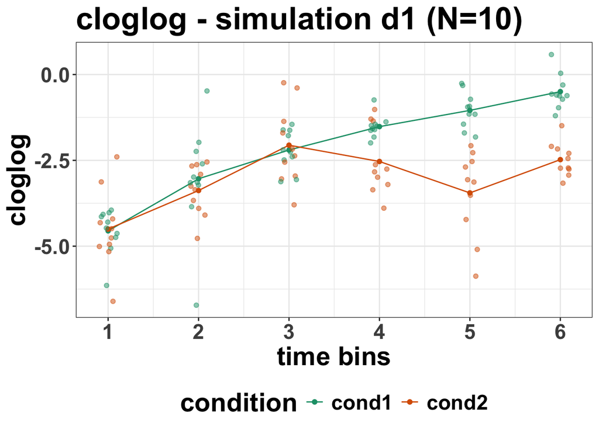

```r
p5.1 <- ggplot(d1_group, aes(x = bin, y = cloglog, colour = condition)) +
  geom_line(aes(group = condition)) +
  geom_point() +
  geom_jitter(data = d1_pid, alpha = 0.5, width = 0.1, height = 0) +
  # scale_y_continuous(limits = c(0,1), breaks = seq(0,1,0.25)) +
  scale_x_continuous(breaks = 1:bin_n, labels = 1:bin_n) +
  scale_fill_brewer(palette = "Dark2") +
  scale_colour_brewer(palette = "Dark2") +
  labs(
    title = "cloglog - simulation d1 (N=10)",
    x = "time bins"
  )
p5.1
```

event prob

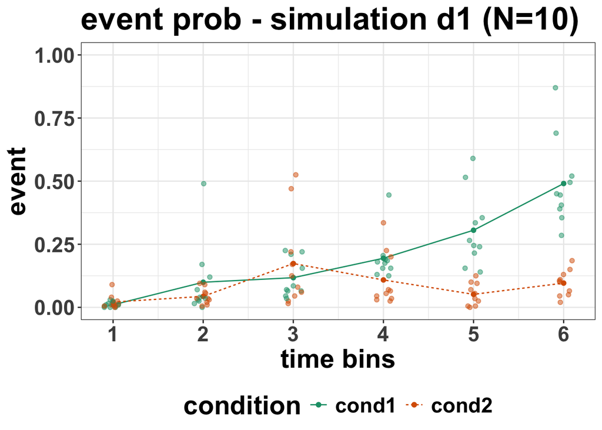

```r
p5.2 <- ggplot(d1_group, aes(x = bin, y = event, colour = condition)) +
  geom_line(aes(group = condition, linetype = condition)) +
  geom_point() +
  geom_jitter(data = d1_pid, alpha = 0.5, width = 0.1, height = 0) +
  scale_y_continuous(limits = c(0, 1), breaks = seq(0, 1, 0.25)) +
  scale_x_continuous(breaks = 1:bin_n, labels = 1:bin_n) +
  scale_fill_brewer(palette = "Dark2") +
  scale_colour_brewer(palette = "Dark2") +
  labs(
    title = "event prob - simulation d1 (N=10)",
    x = "time bins"
  )
p5.2
```

convert the data into outcome data (this next chunk can be incorporated into the data structure chunk above, I’m just doing separately here, so that you can see what is initially generated)

```r
d1_out <- d1 |>
  group_by(subj, rep, condition) |>
  mutate(
    cumsum = cumsum(event),
    outcomel = event == 1 & cumsum(event) < 2,
    outcomen = if_else(event == 1 & cumsum(event) == 1, 1,
      if_else(cumsum(event) >= 1, NA, 0)
    )
  ) |>
  drop_na(outcomen) |>
  ungroup()
head(d1_out)
```

```
## # A tibble: 6 × 31
##   subj   rep    condition  cond   bin   con   inc  bin1  bin2  bin3  bin4  bin5
##   <chr>  <chr>  <fct>     <dbl> <int> <dbl> <dbl> <dbl> <dbl> <dbl> <dbl> <dbl>
## 1 subj01 rep001 cond1         0     1     1     0     1     0     0     0     0
## 2 subj01 rep001 cond1         0     2     1     0     0     1     0     0     0
## 3 subj01 rep001 cond2         1     1     0     1     1     0     0     0     0
## 4 subj01 rep001 cond2         1     2     0     1     0     1     0     0     0
## 5 subj01 rep001 cond2         1     3     0     1     0     0     1     0     0
## 6 subj01 rep002 cond1         0     1     1     0     1     0     0     0     0
## # ℹ 19 more variables: bin6 <dbl>, u1c <dbl>, u2c <dbl>, u3c <dbl>, u4c <dbl>,
## #   u5c <dbl>, u6c <dbl>, u1i <dbl>, u2i <dbl>, u3i <dbl>, u4i <dbl>,
## #   u5i <dbl>, u6i <dbl>, cloglog <dbl>, prob <dbl>, event <int>, cumsum <int>,
## #   outcomel <lgl>, outcomen <dbl>
```

```r
## save outcome data
# write_csv(d1_out, "Tutorial_4_planning/data/d1_out.csv")
```

summarise the outcome data, which is produced based on the prob value, right?

```r
d1_out_pid <- d1_out |>
  group_by(subj, condition, bin) |>
  summarise(outcome = mean(outcomen, na.rm = TRUE)) |>
  mutate(
    prime = if_else(condition == "cond1", "con", "inc"),
    prime = factor(prime)
  )
d1_out_pid
```

```
## # A tibble: 120 × 5
## # Groups:   subj, condition [20]
##    subj   condition   bin outcome prime
##    <chr>  <fct>     <int>   <dbl> <fct>
##  1 subj01 cond1         1  0      con
##  2 subj01 cond1         2  0.49   con
##  3 subj01 cond1         3  0.0490 con
##  4 subj01 cond1         4  0.175  con
##  5 subj01 cond1         5  0.0875 con
##  6 subj01 cond1         6  0.288  con
##  7 subj01 cond2         1  0.0150 inc
##  8 subj01 cond2         2  0.0305 inc
##  9 subj01 cond2         3  0.545  inc
## 10 subj01 cond2         4  0.0345 inc
## # ℹ 110 more rows
```

```r
d1_out_group <- d1_out |>
  group_by(condition, bin) |>
  summarise(outcome = mean(outcomen, na.rm = TRUE)) |>
  mutate(
    prime = if_else(condition == "cond1", "con", "inc"),
    prime = factor(prime)
  )
d1_out_group
```

```
## # A tibble: 12 × 4
## # Groups:   condition [2]
##    condition   bin outcome prime
##    <fct>     <int>   <dbl> <fct>
##  1 cond1         1  0.0100 con
##  2 cond1         2  0.0995 con
##  3 cond1         3  0.121  con
##  4 cond1         4  0.195  con
##  5 cond1         5  0.322  con
##  6 cond1         6  0.5    con
##  7 cond2         1  0.0210 inc
##  8 cond2         2  0.0429 inc
##  9 cond2         3  0.178  inc
## 10 cond2         4  0.108  inc
## 11 cond2         5  0.0473 inc
## 12 cond2         6  0.0963 inc
```

plot outcome using the prime variable to make it comparable to the raw data

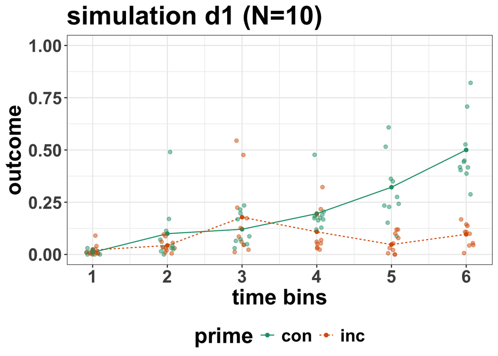

```r
p5.3 <- ggplot(d1_out_group, aes(x = bin, y = outcome, colour = prime)) +
  geom_line(aes(group = prime, linetype = prime)) +
  geom_point() +
  geom_jitter(data = d1_out_pid, alpha = 0.5, width = 0.1, height = 0) +
  scale_y_continuous(limits = c(0, 1), breaks = seq(0, 1, 0.25)) +
  scale_x_continuous(breaks = 1:bin_n, labels = 1:bin_n) +
  scale_colour_brewer(palette = "Dark2") +
  labs(
    title = "simulation d1 (N=10)",
    x = "time bins",
    y = "outcome"
  )
p5.3
```

compare the raw data to the simulated data for a single simulated dataset

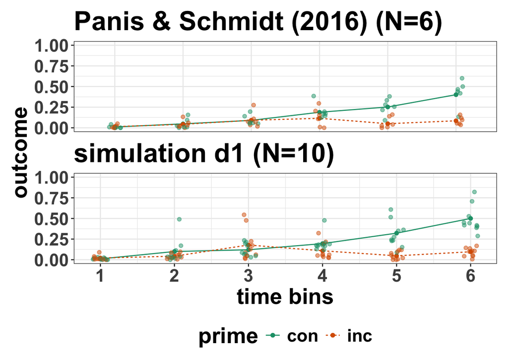

```r
p5.4 <- (p3.1 / p5.3) +
  plot_layout(
    guides = "collect",
    axes = "collect"
  )
p5.4
```

```r
ggsave("Tutorial_4_planning/figures/raw_vs_d1.jpeg",
  width = 8, height = 8, dpi = 800
)
```

ok, this looks reasonably sensible.